# Practical Machine Learning Final Project

Samuel Quiroga

October 17, 2018

```r
knitr::opts_chunk$set(echo = TRUE)
library(tidyverse)
library(caret)
library(parallel)
library(doParallel)
library(AppliedPredictiveModeling)
```

## Practical Machine Learning Peer-graded Assignment

### Exectuive Summary

The goal of this assignment is to predict whether the manner in which an exercise was performed correctly or incorrectly. The data was collected from a study where six participants were asked to perform one set of 10 repetitions of the Unilateral Dumbbell Biceps Curl in 5 different ways (classes A through E). For more information on this study, please go to [http://groupware.les.inf.puc-rio.br/har].

### Getting and cleaning data

Download datasets from links provided.

```r
url.training <- "https://d396qusza40orc.cloudfront.net/predmachlearn/pml-training.csv"
url.testing <- "https://d396qusza40orc.cloudfront.net/predmachlearn/pml-testing.csv"
# check if directory exists
if(!file.exists("data")){dir.create("data")}
# download data to working directory ("data" folder)
download.file(url.training,"./data/training.csv")
download.file(url.testing,"./data/testing.csv")
```

Load the training and testing datasets into the R environment.We also assign `NA` values here.

```r
training.raw <- read.csv("./data/training.csv",na.strings = c("","#DIV/0!","NA"))
test.raw <- read.csv("./data/testing.csv",na.strings = c("","#DIV/0!","NA"))
```

Taking a look at the dimensions of the training data, we can see that it has 19622 observations and 160 variables.

```r
dim(training.raw)
```

```
## [1] 19622   160
```

We should first understand how many null values are in each colum so that in case there are columns with large amount of `NULL` values, for example more than 95%, then we can safetly remove those variables from the prediction model.

```r
null.cols <- as.data.frame(apply(training.raw,2,function(x){sum(is.na(x))}))
colnames(null.cols) <- "Total.Num.Null"; null.cols <- null.cols %>%
        rownames_to_column("Variable") %>%
        filter(Total.Num.Null > 0) # filter out columns that do not contain any NULL value
head(null.cols,10)
```

```
##                Variable Total.Num.Null
## 1    kurtosis_roll_belt          19226
## 2   kurtosis_picth_belt          19248
## 3     kurtosis_yaw_belt          19622
## 4    skewness_roll_belt          19225
## 5  skewness_roll_belt.1          19248
## 6     skewness_yaw_belt          19622
## 7         max_roll_belt          19216
## 8        max_picth_belt          19216
## 9          max_yaw_belt          19226
## 10        min_roll_belt          19216
```

The table above shows 10 out of 100 columns that contain more than one `NULL` value.Below is a summary of columns with null values:

```r
summary(null.cols)
```

```
##    Variable         Total.Num.Null
##  Length:100         Min.   :19216
##  Class :character   1st Qu.:19216
##  Mode  :character   Median :19216
##                     Mean   :19251
##                     3rd Qu.:19225
##                     Max.   :19622
```

Therefore, we see that out of 160 variables in the dataset, 100 (62.5%) of them have at least 19216 null values, which is 97.9% of all the observations. Therefore we will remove these 100 columns from the training and test data sets for modeling purposes.

Now, we are taking the deliberate approach of removing some variables. We will remove the `X` (row names), `raw_timestamp_part_1`, `raw_timestamp_part_2`, `cvtd_timestamp` (all time series), `new_window` and `num_window` columns as it is assumed that this will not be used for predicting the class variable. The assumption is based on the fact that the time will not affect the type `classe`.

```r
cols.remove <- null.cols$Variable
training.main <- training.raw %>% select(
                                         -X,
                                         -raw_timestamp_part_1,-raw_timestamp_part_2,
                                         -cvtd_timestamp,-new_window,-num_window,
                                         -cols.remove)
test.main <- test.raw %>% select(
                                 -X,
                                 -raw_timestamp_part_1,-raw_timestamp_part_2,
                                 -cvtd_timestamp,-new_window,-num_window,
                                 -cols.remove)
dim(training.main)
```

```
## [1] 19622    54
```

We see that our training data set is now 54 columns, including the variable we want to predict `classe` (down from 160). This datset will be used to model the `classe` variable.

### Data Visualization

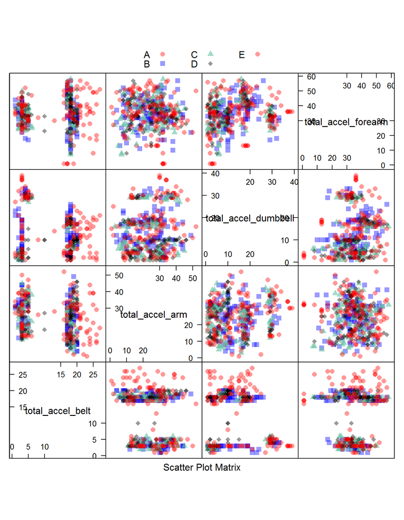

```r
# resample data
training.sample <- training.main %>%
        select(matches("total_accel|classe")) %>%
        group_by(classe) %>%
        sample_n(100)
# create plot
transparentTheme(trans = 0.4)
featurePlot(x=training.sample[,names(training.sample)!="classe"],
            y = training.sample$classe,
            plot = "pairs",
            ## add key at the top
            auto.key = list(columns=3))
```

We can observe that for some of the plots, there are clear variations in the data while others contain clusters that can be split.

### Pre-Processing

Check for near-zero variance predictor and identify and remove if they exist prior to modelling.

```r
nzv <- nearZeroVar(training.main)
filt.temp <- training.main[,-nzv]
dim(filt.temp)
```

```
## [1] 19622     0
```

Therefore we can see that there are not any near-zero variance predictors in the dataset.

We should also identify highly correlated predictors (>99.9% correlation) so that we can remove them if necessary

```r
dataCorr <- cor(training.main[,-c(1,54)]) # remove variable to predict and user name
highCorr <- sum(abs(dataCorr[upper.tri(dataCorr)]) > .999)
highCorr
```

```
## [1] 0
```

We can see that there no predictors that are highly correlated.

### Develop Model

Since the data size is large enough (>19000 samples) and this is a multi-class classification setting (we are trying to predict different classes in `classe`), we will use repeated k-fold cross validation for this data set. For the prediction method, we wil use Random Forests. First we will set up parallel processing to increase computing speeds.

Set up parallel processing with `parallel` and `doParallel` packages.

```r
cluster <- makeCluster(detectCores()-1)
registerDoParallel(cluster)
```

Since we will do 3 repeats of 10-Fold CV, will need to set a seed for each re-sample to ensure repeatability.

```r
set.seed(654)
my.seeds <- vector(mode="list",length = 31) # generate list of seeds, one for each sample plus 1 (3 repeats * 10 folds + 1)
for(i in 1:30) my.seeds[[i]] <- sample.int(1000,22)
# for the last model
my.seeds[[31]] <- sample.int(1000,1)
```

Configure the trainControl function with repeated cross-validation, re-sampled ten times and repeated 3 times.

```r
train.control <- trainControl(method = "repeatedcv",number=10,repeats = 3,allowParallel = T, seeds = my.seeds)
```

Develope training model using the `trainContro()` object that we just created.

```r
model <- train(classe ~ .,data=training.main,method="rf",trControl=train.control)
```

De-register parallel processing cluster to force R to return to single threaded processing.

```r
stopCluster(cluster)
registerDoSEQ()
```

### Assess Model Accuracy

First see the model results :

```r
model
```

```
## Random Forest
##
## 19622 samples
##    53 predictor
##     5 classes: 'A', 'B', 'C', 'D', 'E'
##
## No pre-processing
## Resampling: Cross-Validated (10 fold, repeated 3 times)
## Summary of sample sizes: 17661, 17659, 17659, 17659, 17660, 17659, ...
## Resampling results across tuning parameters:
##
##   mtry  Accuracy   Kappa
##    2    0.9947337  0.9933381
##   29    0.9950903  0.9937895
##   57    0.9901468  0.9875353
##
## Accuracy was used to select the optimal model using the largest value.
## The final value used for the model was mtry = 29.
```

Fold accuracy : we can also observe the accuracy for each fold.

```r
model$resample
```

```
##     Accuracy     Kappa    Resample
## 1  0.9959246 0.9948442 Fold02.Rep1
## 2  0.9949006 0.9935494 Fold01.Rep1
## 3  0.9954152 0.9942003 Fold04.Rep1
## 4  0.9964340 0.9954894 Fold03.Rep1
## 5  0.9928571 0.9909630 Fold09.Rep1
## 6  0.9959225 0.9948426 Fold05.Rep1
## 7  0.9918451 0.9896845 Fold04.Rep2
## 8  0.9938838 0.9922638 Fold10.Rep1
## 9  0.9949058 0.9935564 Fold06.Rep1
## 10 0.9938869 0.9922675 Fold05.Rep2
## 11 0.9959246 0.9948451 Fold01.Rep2
## 12 0.9959225 0.9948423 Fold07.Rep1
## 13 0.9964322 0.9954865 Fold06.Rep2
## 14 0.9959204 0.9948393 Fold02.Rep2
```

[output cut: 16 more lines]

See the confustion matrix

```r
confusionMatrix(model)
```

```
## Cross-Validated (10 fold, repeated 3 times) Confusion Matrix
##
## (entries are percentual average cell counts across resamples)
##
##           Reference
## Prediction    A    B    C    D    E
##          A 28.4  0.1  0.0  0.0  0.0
##          B  0.0 19.2  0.1  0.0  0.0
##          C  0.0  0.0 17.3  0.1  0.0
##          D  0.0  0.0  0.0 16.3  0.0
##          E  0.0  0.0  0.0  0.0 18.3
##
##  Accuracy (average) : 0.9951
```

Therefore we can see that we have attained a model accuracy of 99.5% using repeated k-fold cross validation.Therefore, the out of sample error is 0.5%.

### Predict on Test data

Uing the test data `test.main` we can predict the `problem_id` variable with 100% prediction rate based on the results of the Course Project Prediction Quiz.

```r
predictions <- predict(model,newdata = test.main)
data.frame(id=test.main$problem_id,predictions=predictions)
```

```
##    id predictions
## 1   1           B
## 2   2           A
## 3   3           B
## 4   4           A
## 5   5           A
## 6   6           E
## 7   7           D
## 8   8           B
## 9   9           A
## 10 10           A
## 11 11           B
## 12 12           C
## 13 13           B
## 14 14           A
## 15 15           E
## 16 16           E
## 17 17           A
## 18 18           B
## 19 19           B
## 20 20           B
```